# Cooktop Preference Analysis

Team Cooktop

Author

Hanna Song, Paul Derisemu, Tejas Phirke, Zain Hoda

Published

December 2, 2023

# Abstract

Our project is to identify people’s preferences for different types of stoves –Gas, Electric and Induction. The motivation behind this study is the US Government’s proposed shift to transition from gas to electric/induction stoves for safety and environmental reasons.

Our preliminary research about [Cooktop types](https://docs.google.com/spreadsheets/d/1t7P-EwncM1di8XoGIacFEEggvDJcXtPfUdSaPnEAlM4/edit?usp=sharing) helped us determine the features people are interested in while purchasing cooking stoves: Type, Final Cost, Number of Burners, Average Annual Usage Cost and Indoor Air Quality. Using these attributes, we are designing a survey and will be performing a Conjoint analysis of the results to better understand user preferences. The eventual goal is to be able to provide insights to policymakers for refining existing policies and facilitating a smooth shift from gas to electricity. Some of the insights we have gained from our pilot analysis were including both gender and Age in the preliminary questions would help us better understand our audience and that our exclusion criteria in the survey design should only be for underage individuals as we have limited resources for conducting surveys. The exclusion criteria of residence in the DMV region and Home Ownership should ideally be moved upstream to the respondents’ selection platform ie. MTurk

# Introduction

Cooking is an essential part of daily life, and the cooktop individuals choose can significantly impact their culinary experience. Whether an individual is a professional chef or simply enjoys preparing meals at home, their preferences for cooktop types can vary widely. On the other hand, the shift from traditional gas stoves to induction or electric stoves has been a rising debate among climate advocates who have been proposing a reduction of fossil fuel usage. Considering all these factors, the US government brought in a law [(Inflation Reduction Act 2022)](https://www.democrats.senate.gov/imo/media/doc/inflation_reduction_act_of_2022.pdf) which amongst many other considerations is subsidies to homeowners who switch from gas to Electric/Induction Stoves.

The motivation behind our study is the proposed shift from gas to electric/Induction and the practical challenges that will come during its implementation. There is a genuine individual safety concern with gas cooktops and their adverse effects on the environment, on the other hand, the concerns of the people who are being asked to switch are equally valid. The cost differential, reliability, and efficacy while preparing certain cuisines are just some of the primary concerns that come up when considering a transition from gas to electric/induction.

### Type of Cooktops:

- Gas Cooktop - Gas Cooktops work on natural gas which is ignited and the flame itself is the source of heat. It was patented by James Sharp in England in 1826 and has been an integral part of most households since the 1920’s.
- Electric Cooktop - Electric cooktops have an electrical current that flows through a metal coil underneath the glass or ceramic surface. The coil becomes hot and starts glowing due to the electrical resistance. It will transfer its heat through the glass using infrared energy. It was patented in 1896 by William Hadaway.
- Induction Cooktop - Induction cooktops generate heat by combining electricity and the magnetic properties found in most pots and pans. Induction Cooktops were first released to the public at the Chicago “Century of Progress” World’s Fair in 1933.

[video not shown]

### Product Attributes and Decision Variables

We have limited our study to easily quantifiable attributes like Type of stove, Final Cost, Number of Burners, Average Annual Usage Cost, and Indoor Air Quality to understand user preferences as these are readily available and widely understandable. Reliability of technology and Cooking Efficacy are factors that are beyond the users’ control and that is why we have not considered those.

| Attributes | Type | Value / Range |
| --- | --- | --- |
| Cooktop Type | Discrete | Gas, Electric, Induction |
| Final Cost Price | Continuous | 500, 700, 900, 1100, 1300, 1500 |
| Average Annual Usage Cost | Continuous | 50, 60, 70, 80, 90, 100 |
| Number of Burners | Discrete | 3, 4, 5 |

# Survey Design

### Eligibility

Our eligibility criteria was Homeowners in US. We chose homeowners because Cooktops are bought by Homeowners and we wanted to gauge the preferences of the people. We had earlier thought about restricting ouselves to the DMV region but we could not find enough survey participants so we expanded our criteria. This was in addition to the necessary requirement of being over 18 and providing consent for the survey.

### Respondent information

Along with the eligibility question, we were interested in obtaining information of people owning their household and how often they are cooking at home. We asked about the respondents’ Year of Birth, their place of residence, and their frequency of cooking. We also collected information about gender, salary range and if they have a gas connection in their homes.

### Attributes and levels for Conjoint Quesitons:

Our conjoint questionnaire consisted of 8 questions after filtering out people from eligibility questions. Each question consists of 3 choices with each type of cooktop, final cost price, average annual usage cost and number of burners. After asking their preference questions, we asked for the heating efficiency and concerns of emissions from each respondent.

### Educational material presented to the respondents.

- Cooktop type: Type of cooktop you prefer between gas, electric and induction.
- Final cost price: Total price to buy and setup the stove to get it running including taxes
- Average annual usage cost: Average price/yr to maintain the stove, like the price paid to gas or electricity
- Indoor air quality: Quality of the air in a home, school, office, or other building environment
- Number of burners in the cooktop: 3, 4, 5
- Emissions: Average amount of carbon emissions your stove will emit in a year
- Heating efficiency: This is time taken by the stove to reach cooking temperatures. Induction stoves take the shortest time to reach cooking temperature followed by electric and gas stoves.
- Induction cookware: Induction compatible cookware are required while using Induction stoves. You can tell if your cookware is suitable for induction cooking if it has a coil symbol on the base, or if a magnet clings firmly to the cookware’s underside. If you test a cookware and the magnet only sticks loosely to the base, you may find the cookware does not heat as effectively.

### Example figure of a random Conjoint Question

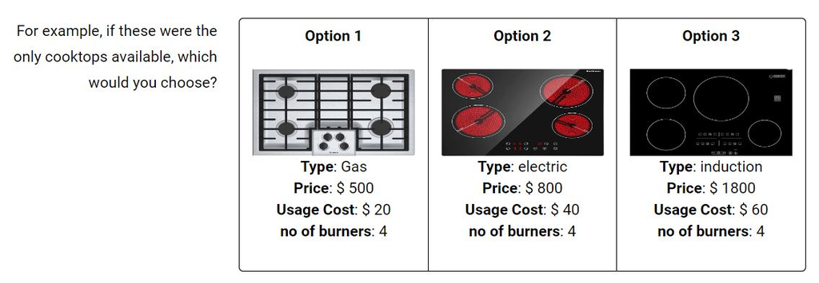

# Data Analysis

## Sample Description

We had 210 respondents for our survey who completed all the choice questions after filtering for consent and eligibility criteria. After that, we filtered out people who did not spend a reasonable time on the survey (those who went too fast), and we were left with 189 respondents. We further analyzed our respondents based on their demographics like age bracket, income range, and gender.

[output not shown]

Education Distribution:

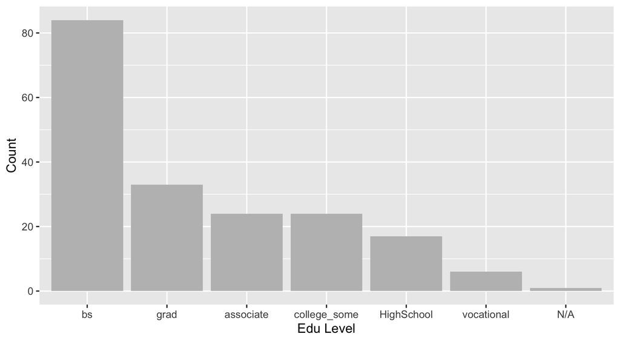

```r
education_info <- c("bs", "vocational", "college_some", "HighSchool", "grad", "associate", "N/A")
number_of_people <- c(84, 6, 24, 17, 33, 24, 1)
df_Education <- data.frame(Education = education_info, Count = number_of_people)
ggplot(df_Education, aes(x=reorder(Education, -Count), y=number_of_people)) +
  geom_bar(stat='identity')+
  geom_col(fill = "grey") +
  labs(x = 'Edu Level', y = 'Count')
```

Income Distribution:

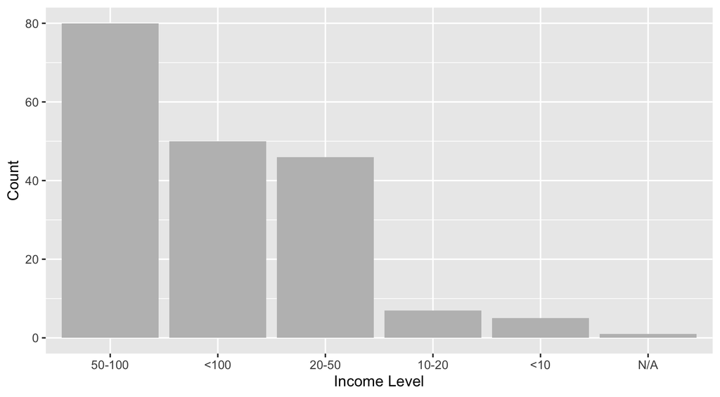

```r
income_info <- c("<10", "20-50", "50-100", "<100", "10-20", "N/A")
number_of_people <- c(5, 46, 80, 50, 7, 1)
df_Income <- data.frame(Income = income_info, Count = number_of_people)
ggplot(df_Income, aes(x=reorder(Income, -Count), y=number_of_people)) +
  geom_bar(stat='identity')+
  geom_col(fill = "grey") +
  labs(x = 'Income Level', y = 'Count')
```

## Data cleaning

- We added formr respondents data per each survey.
- We combined them into one data frame
- We filtered out respondents who responded “No” to consent age and consent understanding
- We filtered out respondents who did not finish the survey.
- We filtered out respondents who replied too fast using the time column.
- We filter people who got our attention-check questions wrong
- The remaining data was our analysis and model-building data.

## Modeling

For our final analysis, we have built multiple models which are listed below.

### Simple Logit Model

A simple preference based model with all features (Final Cost Price, Average Annual Cost Price, Number of Burners and Type of Cooktop)

$$u_{j} = \beta_{1}x_{j}^{final\;cost\;price} + \beta_{2}x_{j}^{average\;annual\;usage\;cost}
+\beta_{3}\delta_{j}^{number\;of\;burners\;4}
+\beta_{4}\delta_{j}^{number\;of\;burners\;5}
+\beta_{5}\delta_{j}^{cooktop\;type\;electric}
+\beta_{6}\delta_{j}^{cooktop\;type\;induction}$$

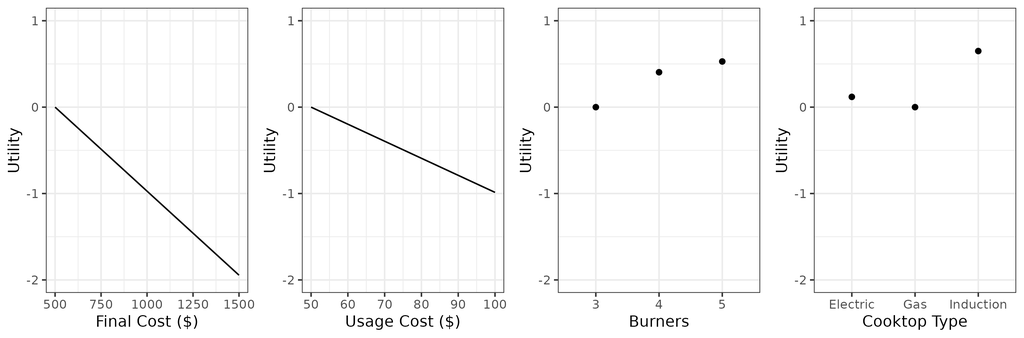

```r
knitr::include_graphics("./figs/model_simple_utility.png")
```

Observations:

- We observe a drop in utility with the increase in price for both “Final Cost of Burners” and “Average Annual Usage Costs” which is expected behavior.
- For the “# of Burners”, we can clearly see that there is a significant increase in utility from 3 stove burner to 4 stove burners but not so much while moving from 4 to 5 burners. We can infer from this that companies should focus more on 4 burners than 5 burners as the increase in utility is low.
- The final observation from the “Cooktop Type” graph is that utility for Induction stove is higher than electric and gas.

### Mixed Logit Model

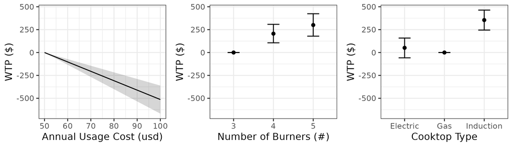

```r
knitr::include_graphics("./figs/plot_mxl_wtp.png")
```

### Subgroup Analysis

We identified subgroups in our population based on education and Income.

#### Education Sub-Groups

Those who completed their Master’s or bachelor’s degree were marked as ‘high’ in education level and others with lower educational qualifications were marked as ‘low’.

Education Level - High

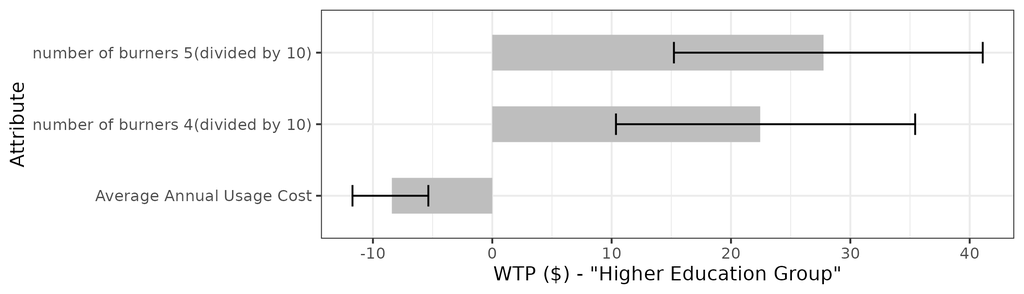

```r
knitr::include_graphics("./figs/barplot_mnl_wtp_high.png")
```

Education Level - Low

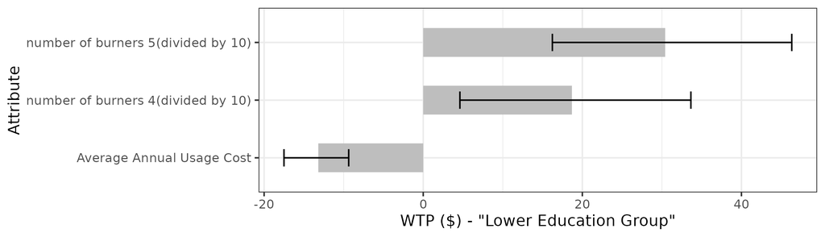

```r
knitr::include_graphics("./figs/barplot_mnl_wtp_low.png")
```

Observations:

- There is a positive Willingness to Pay for 4 and 5 burner stoves in both lower and higher education groups but the increase in ‘WTP’ from 4 burner to 5 burner stove is higher in Lower education group.
- The negative Willingness to Pay for ‘Average Annual Usage Cost’ is more in lower education group which indicates they are willing to pay a “higher” total upfront cost to decrease their Average annual usage cost.

#### Income Sub-Groups

Those who reported their annual income over $100,000 were identified as “High Income Group”, income range from $50,000 - $100,000 was identified as “Mid Income Group” and below $50,000 as “Low Income Group”

Income Level - High

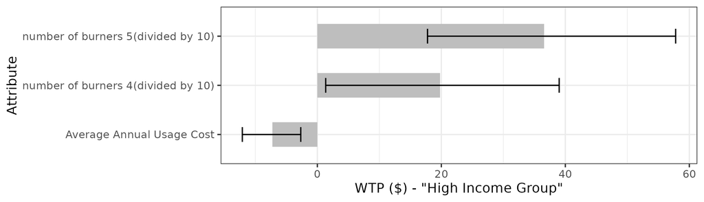

```r
knitr::include_graphics("./figs/barplot_mnl_wtp_income_high.png")
```

Income Level - Mid

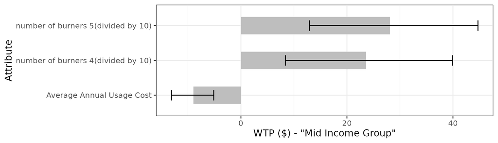

```r
knitr::include_graphics("./figs/barplot_mnl_wtp_income_mid.png")
```

Income Level - Low

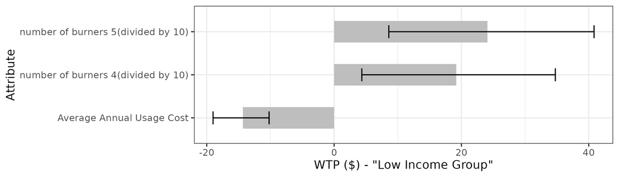

```r
knitr::include_graphics("./figs/barplot_mnl_wtp_income_low.png")
```

Observations:

- There is a positive Willingness to Pay for 4 and 5 burner stoves in all Income groups but the increase in ‘WTP’ from 4 burner to 5 burner stove is high in high-income group while it is significantly lower in the other groups.
- The negative Willingness to Pay for ‘Average Annual Usage Cost’ is significantly higher in lower income group compared to others which indicates they are willing to pay a “higher” total upfront cost to decrease their Average annual usage cost.

# Results

### Willingness to Pay Model

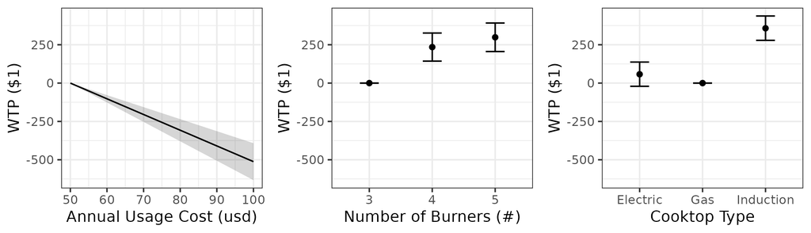

```r
knitr::include_graphics("./figs/model_wtp_cooktop_4a.png")
```

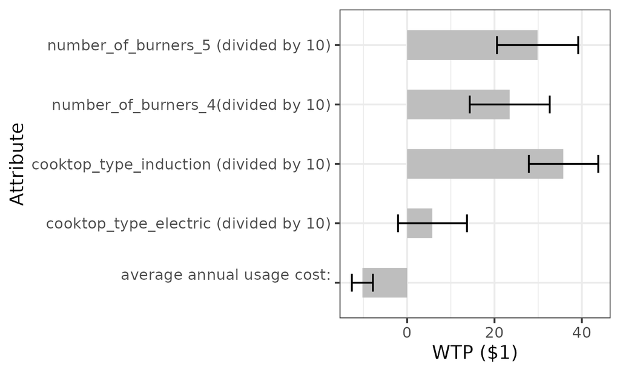

```r
knitr::include_graphics("./figs/model_wtp_4a_barplot.png")
```

Observations:

- From the WTP model, we can see that there is a strong negative WTP for ‘Average annual usage cost’ and the respondents are willing to pay a “higher” total upfront cost to decrease their Average annual usage cost.
- There is a significant WTP increase from 3 burner to 4 burner (roughly $250) but a small WTP increase from 4 burner to 5 burner.
- There is significant WTP increase from gas to Induction cooktop type (roughly $350) but a small WTP increase from gas to Electric burner.

## Simulation

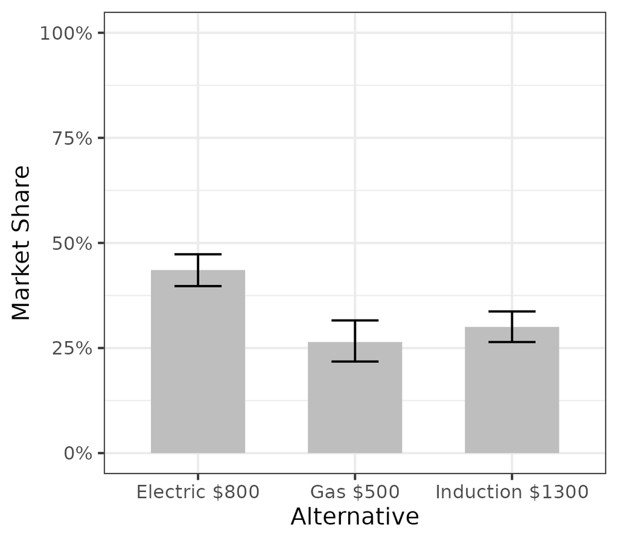

```r
knitr::include_graphics("./figs/sim.png")
```

In the baseline case we have taken the approximate average market price of each type of stove (gas $500, electric $800 and induction $1300) and based on our model, the market share of Induction is close to 30%.

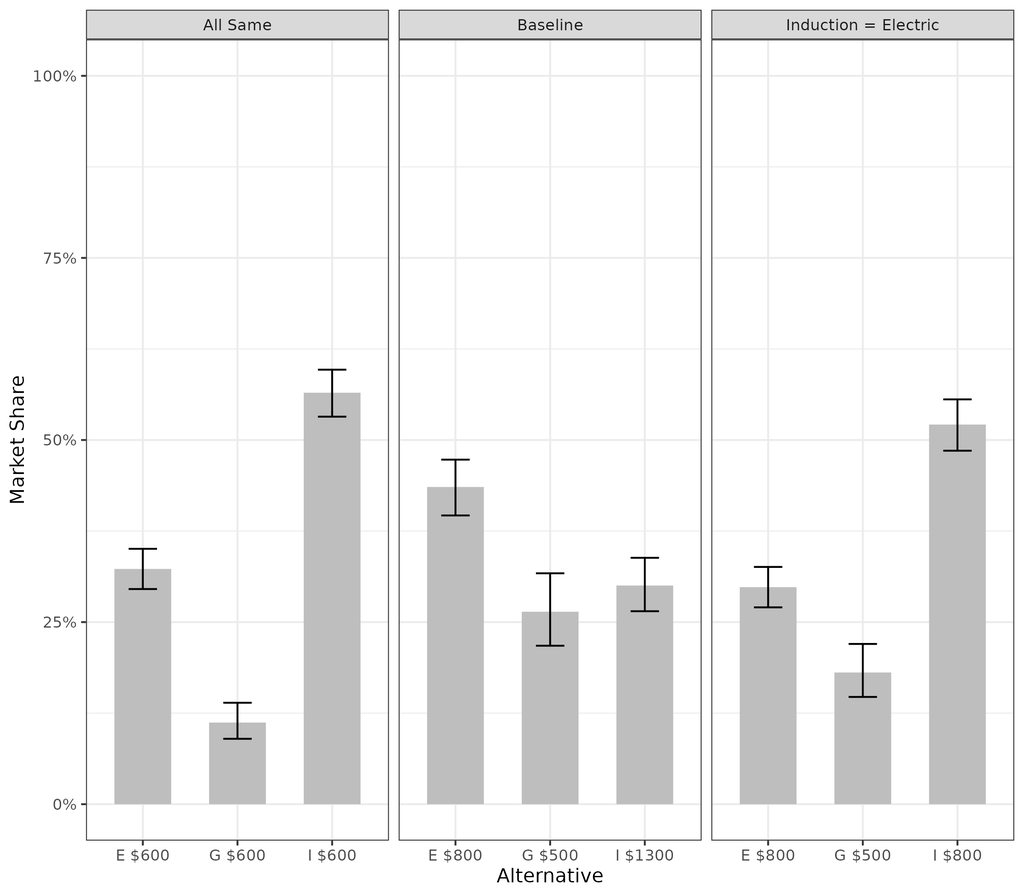

```r
knitr::include_graphics("./figs/sim_multi.png")
```

In the above graph, we are showing three scenarios with different prices of the stoves (Gas, Electric and Induction) and their respective market shares.

## Sensitivity Analysis

Induction Cooktop market share sensitivity to price

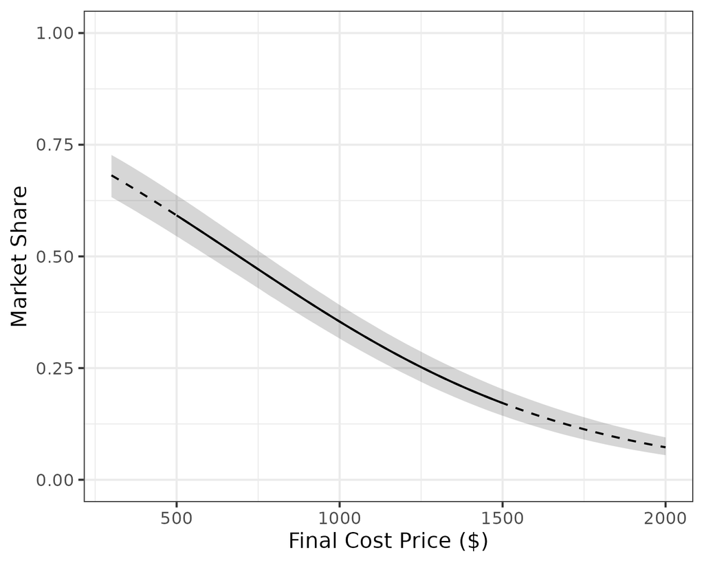

```r
knitr::include_graphics("./figs/share_price_plot.png")
```

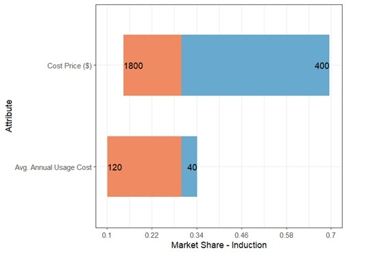

```r
knitr::include_graphics("./figs/tornado.jpg")
```

Induction Cooktop - Revenue Trend

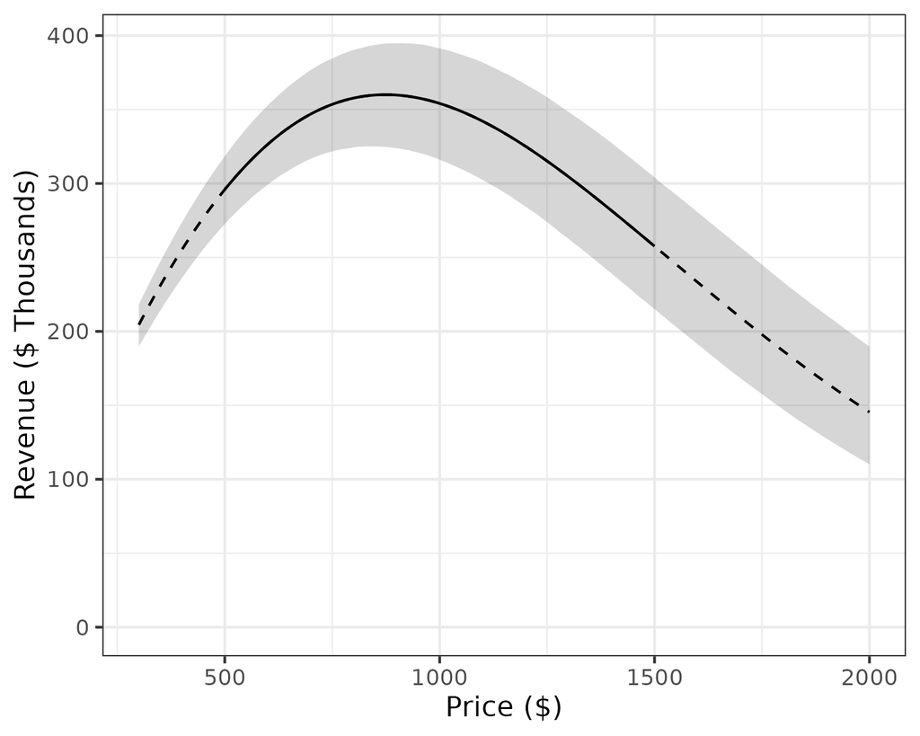

```r
knitr::include_graphics("./figs/rev_price_plot.png")
```